# White-Britt-ADA-homework-3

BA White

5/3/2020

Load packages and dataset

```r
library(tidyverse)
library(curl)
library(dplyr)
read <- curl("https://raw.githubusercontent.com/difiore/ADA-datasets/master/KamilarAndCooperData.csv")
data <- read.csv(read, header = TRUE, sep = ",", stringsAsFactors = FALSE)
head(data)
```

```
##               Scientific_Name          Family          Genus      Species
## 1 Allenopithecus_nigroviridis Cercopithecidae Allenopithecus nigroviridis
## 2         Allocebus_trichotis Cercopithecidae      Allocebus    trichotis
## 3           Alouatta_belzebul        Atelidae       Alouatta     belzebul
## 4             Alouatta_caraya        Atelidae       Alouatta       caraya
## 5            Alouatta_guariba        Atelidae       Alouatta      guariba
## 6           Alouatta_palliata        Atelidae       Alouatta     palliata
##   Brain_Size_Species_Mean Brain_Size_Female_Mean   Brain_size_Ref
## 1                   58.02                  53.70 Isler et al 2008
## 2                      NA                     NA
## 3                   52.84                  51.19 Isler et al 2008
## 4                   52.63                  47.80 Isler et al 2008
## 5                   51.70                  49.08 Isler et al 2008
## 6                   49.88                  48.04 Isler et al 2008
##   Body_mass_male_mean Body_mass_female_mean Mass_Dimorphism
```

[output cut: 62 more lines]

## Challenge 1

Aim: Fit a simple linear regression model to predict longevity (MaxLongevity_m) measured in months from species’ brain size (Brain_Size_Species_Mean). Task: For both longevity~brain size and log(longevity)~log(brain size) complete the following:

```r
# Fit the regression model and, using {ggplot2}
lm <- lm(Brain_Size_Species_Mean ~ MaxLongevity_m, data)
summary(lm)
```

```
##
## Call:
## lm(formula = Brain_Size_Species_Mean ~ MaxLongevity_m, data = data)
##
## Residuals:
##      Min       1Q   Median       3Q      Max
## -127.756  -25.855   -3.442   19.405  293.608
##
## Coefficients:
##                 Estimate Std. Error t value Pr(>|t|)
## (Intercept)    -65.36266   13.05712  -5.006 1.83e-06 ***
## MaxLongevity_m   0.40458    0.03657  11.064  < 2e-16 ***
## ---
## Signif. codes:  0 '***' 0.001 '**' 0.01 '*' 0.05 '.' 0.1 ' ' 1
##
## Residual standard error: 52.4 on 126 degrees of freedom
##   (85 observations deleted due to missingness)
## Multiple R-squared:  0.4928, Adjusted R-squared:  0.4887
## F-statistic: 122.4 on 1 and 126 DF,  p-value: < 2.2e-16
```

```r
data <- data %>%
  mutate(log_BMASSFM = (log(Body_mass_female_mean)),
  logMaxLongevity = (log(MaxLongevity_m)))

loglm <-lm(log_BMASSFM ~ logMaxLongevity, data)
summary(loglm)
```

```
##
## Call:
## lm(formula = log_BMASSFM ~ logMaxLongevity, data = data)
##
## Residuals:
##      Min       1Q   Median       3Q      Max
## -2.15852 -0.77475  0.03331  0.81127  2.33681
##
## Coefficients:
##                 Estimate Std. Error t value Pr(>|t|)
## (Intercept)      -7.9117     1.2812  -6.175 6.84e-09 ***
## logMaxLongevity   2.7322     0.2231  12.247  < 2e-16 ***
## ---
## Signif. codes:  0 '***' 0.001 '**' 0.01 '*' 0.05 '.' 0.1 ' ' 1
##
## Residual standard error: 1.007 on 139 degrees of freedom
##   (72 observations deleted due to missingness)
## Multiple R-squared:  0.519,  Adjusted R-squared:  0.5155
## F-statistic:   150 on 1 and 139 DF,  p-value: < 2.2e-16
```

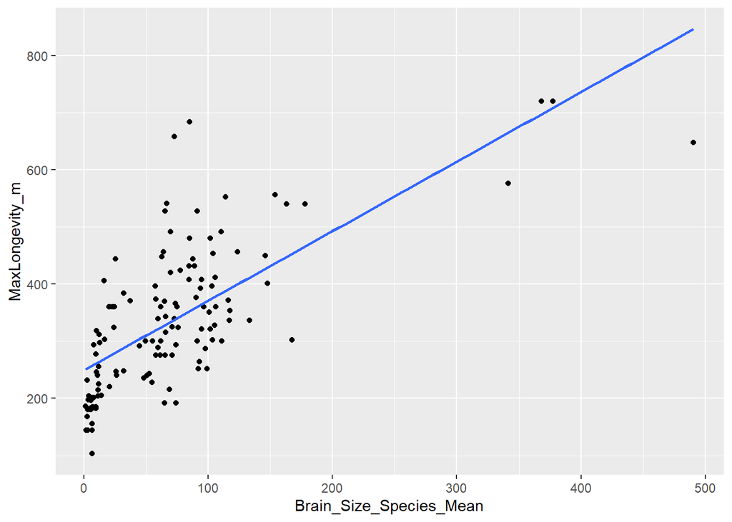

```r
# produce a scatterplot with the fitted line
(plotlm <- ggplot(lm, aes(Brain_Size_Species_Mean, MaxLongevity_m)) + geom_point() + geom_smooth(method="lm", se=FALSE))
```

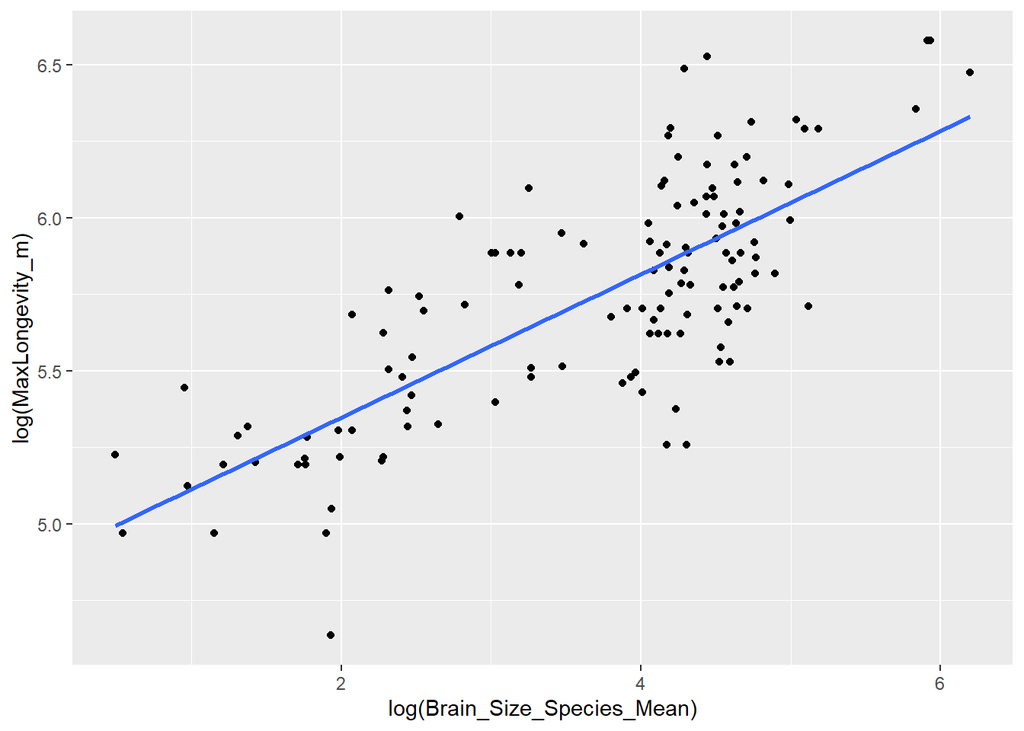

```r
(plotlog_lm <- ggplot(lm, aes(log(Brain_Size_Species_Mean), log(MaxLongevity_m))) + geom_point() + geom_smooth(method="lm", se=FALSE))
```

### Identify and interpret the point estimate of the slope (β1), as well as the outcome of the test associated with the hypotheses

```r
# Y (response variable) = β0 (intercept) + β1Xi (predictor variable)+ ϵi (random error variable)
nanodata<-na.omit(data)
bss<-nanodata$Brain_Size_Species_Mean
lgv<-nanodata$MaxLongevity_m
(pointestimate_slope <- cor(bss, lgv) * (sd(lgv) / sd(bss)))
```

```
## [1] 0.8789037
```

```r
# Since the slope is positive and almost one to one my interpretation is that brain size species means do predict/correlate to longevity.
```

### Find a 90% CI for the slope (β1) parameter.

```r
alpha <- 0.10
# extract CIs from the model with
# using the results of lm()
(CI <- confint(lm, level = 1 - alpha))
```

```
##                       5 %        95 %
## (Intercept)    -86.998791 -43.7265361
## MaxLongevity_m   0.343982   0.4651695
```

```r
(CIlog <- confint(loglm, level = 1 - alpha))
```

```
##                        5 %      95 %
## (Intercept)     -10.033102 -5.790203
## logMaxLongevity   2.362783  3.101640
```

### Add lines for the 90% confidence and prediction interval bands on the plot, and add a legend to differentiate between the lines.

```r
library(broom)
y.hat <- predict(loglm, newdata = data.frame(logMaxLongevity = data$logMaxLongevity))
df <- data.frame(cbind(data$logMaxLongevity, data$log_BMASSFM, y.hat))
names(df) <- c("x", "y", "yhat")
df <- augment(loglm)

# confidence intervals
df <- df %>%
  mutate(
    c.lwr = .fitted - qt(1 - alpha / 2, nrow(df) - 2) * .se.fit,
    c.upr = .fitted + qt(1 - alpha / 2, nrow(df) - 2) * .se.fit
  )

# sd deviation of residuals
sd <- glance(loglm) %>% pull(sigma)

#Now the predicted values
df <- df %>%
# calculate a confidence interval for the predicted values
  mutate(
    se.prediction = sqrt(sd^2 + .se.fit^2),
    p.lwr = .fitted - qt(1 - alpha / 2, nrow(df) - 2) * se.prediction,
    p.upr = .fitted + qt(1 - alpha / 2, nrow(df) - 2) * se.prediction
  )
head(df)
```

```
## # A tibble: 6 x 15
##   .rownames log_BMASSFM logMaxLongevity .fitted .se.fit .resid    .hat .sigma
##   <chr>           <dbl>           <dbl>   <dbl>   <dbl>  <dbl>   <dbl>  <dbl>
## 1 1                8.06            5.62    7.44  0.0883  0.620 0.00768   1.01
## 2 4                8.35            5.50    7.10  0.0996  1.25  0.00979   1.01
## 3 6                8.58            5.70    7.67  0.0850  0.913 0.00713   1.01
## 4 7                8.77            5.48    7.06  0.101   1.71  0.0101    1.00
## 5 8                8.56            5.70    7.67  0.0850  0.886 0.00713   1.01
## 6 9                7.11            5.89    8.17  0.0917 -1.06  0.00829   1.01
## # ... with 7 more variables: .cooksd <dbl>, .std.resid <dbl>, c.lwr <dbl>,
## #   c.upr <dbl>, se.prediction <dbl>, p.lwr <dbl>, p.upr <dbl>
```

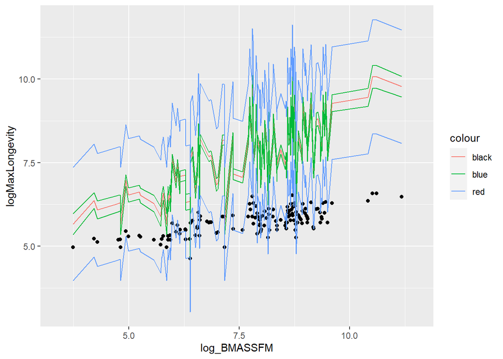

```r
g <- ggplot(data = data, aes(x = log_BMASSFM, y = logMaxLongevity))
g <- g + geom_point()
g <- g + geom_line(data = df,aes(x = log_BMASSFM, y = .fitted, color = "black"), na.rm = TRUE)
g <- g + geom_line(data = df,aes(x = log_BMASSFM, y = c.lwr, color = "blue"), na.rm = TRUE)
g <- g + geom_line(data = df, aes(x = log_BMASSFM, y = c.upr, color = "blue"), na.rm = TRUE)
g <- g + geom_line(data = df,aes(x = log_BMASSFM, y = p.lwr, color = "red"), na.rm = TRUE)
g <- g + geom_line(data = df,aes(x = log_BMASSFM, y = p.upr, color = "red"), na.rm = TRUE)
g
```

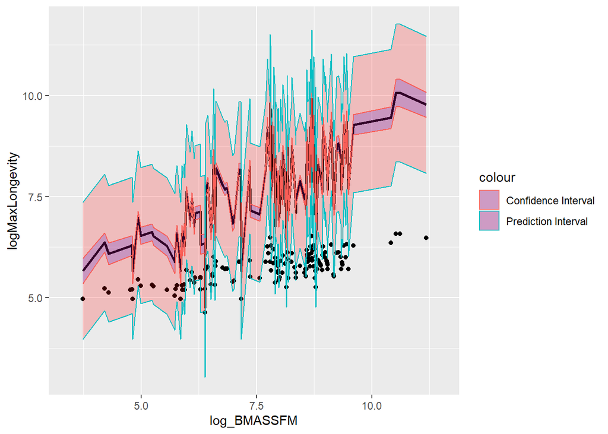

```r
## legend plot
g2 <- ggplot(data = data, aes(x = log_BMASSFM, y = logMaxLongevity), alpha = 0.5) +
  geom_point(na.rm = TRUE) +
  # add regression line
  geom_line(
    data = df, aes(x = log_BMASSFM, y = .fitted), color = "black",
    lwd = 1
  ) +
  # add a ribbon layer
  geom_ribbon(
    data = df, aes(x = log_BMASSFM, ymin = c.lwr, ymax = c.upr, colour = "Confidence Interval"),
    # ... with transparency set to 0.2
    alpha = 0.2,
    # ... and fill color blue
    fill = "blue"
  ) +
  geom_ribbon(
    data = df, aes(x = log_BMASSFM, ymin = p.lwr, ymax = p.upr, colour = "Prediction Interval"),
    # ... with transparency set to 0.2
    alpha = 0.2,
    # ... and fill color red
    fill = "red"
  )
g2
```

```r
(b750 <- 248.9523 + (1.2180 * 750))
```

```
## [1] 1162.452
```

### Do you trust the model to predict observations accurately for this value of the explanatory variable? Why or why not?

To some degree, yes, because the R squared value denotes that almost 50% of the variation can be attributed to the predictor variable and the graph indicates a linear relationship. ### Looking at your two models (i.e., untransformed versus log-log transformed), which do you think is better? Why? Log-transformed model appears to reduce the skew in the magnitude of differences in brain size and longevity from the different species allowing for a one:one, linear model whereas the untransformed data does not show as clear of a correlation because the species brain size and longevity are on different orders of magnitude.

## Challenge 2

### run a linear regression looking at log(HomeRange_km2) in relation to log(Body_mass_female_mean)

```r
data <- data %>%
  mutate(log_BMASSFM = log(Body_mass_female_mean),
  logHOMER = (log(HomeRange_km2)))

rangeLM <- lm(log_BMASSFM ~ logHOMER, data)
```

### report your β coeffiecients (slope and intercept).

```r
summary(rangeLM)
```

```
##
## Call:
## lm(formula = log_BMASSFM ~ logHOMER, data = data)
##
## Residuals:
##      Min       1Q   Median       3Q      Max
## -2.41652 -0.68537  0.07268  0.79696  2.11649
##
## Coefficients:
##             Estimate Std. Error t value Pr(>|t|)
## (Intercept)  8.48616    0.10199   83.20   <2e-16 ***
## logHOMER     0.50638    0.04147   12.21   <2e-16 ***
## ---
## Signif. codes:  0 '***' 0.001 '**' 0.01 '*' 0.05 '.' 0.1 ' ' 1
##
## Residual standard error: 0.9949 on 135 degrees of freedom
##   (76 observations deleted due to missingness)
## Multiple R-squared:  0.5248, Adjusted R-squared:  0.5213
## F-statistic: 149.1 on 1 and 135 DF,  p-value: < 2.2e-16
```

### use bootstrapping to sample from the dataset 1000 times with replacement,

```r
library(infer)
set.seed(213)
bootsbewalkin <- data %>%
  # specify model
  specify(log_BMASSFM ~ logHOMER) %>%
  # generate bootstrap replicates
  generate(reps = 1000, type = "bootstrap") %>%
  # calculate the slope statistic
  calculate(stat = "slope")
```

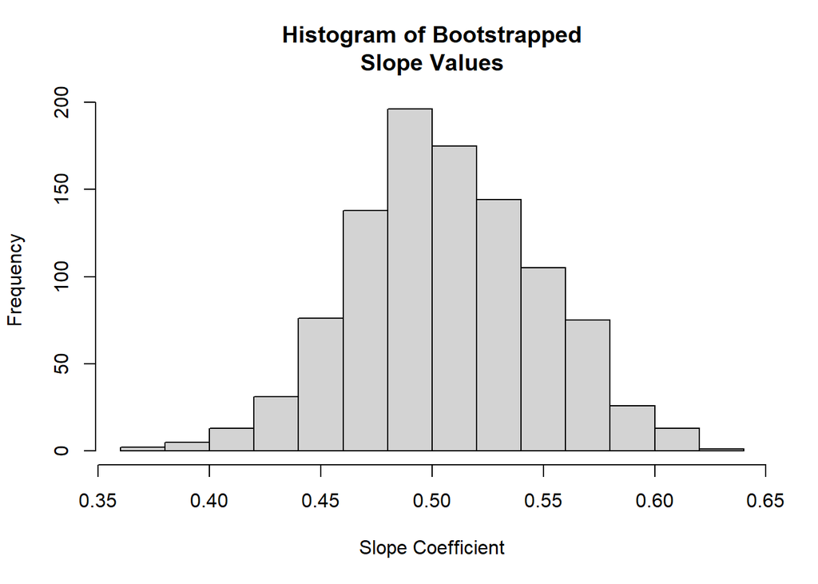

```r
# Histogram
hist(bootsbewalkin$stat,
  main = "Histogram of Bootstrapped\nSlope Values",
  xlab = "Slope Coefficient"
)
```

```r
bootsbewalkin <- data %>%
  # specify model
  specify(log_BMASSFM ~ logHOMER) %>%
  # generate bootstrap replicates
  generate(reps = 1000, type = "bootstrap")
slope <- vector()
intercept <- vector()
for (i in 1:213) {
  Reps <- filter(bootsbewalkin, replicate == i)
  Reps_B <- lm(log_BMASSFM ~ logHOMER, data = Reps)
  slope[[i]] <- Reps_B$coefficients[[2]]
  intercept[[i]] <- Reps_B$coefficients[[1]]
}

# store data points for accesibilty
Brain_Range_Boot <- tibble(slope = slope, intercept = intercept)
```

### Plot a histogram of these (bootstrapping) sampling distributions for β0 and β1

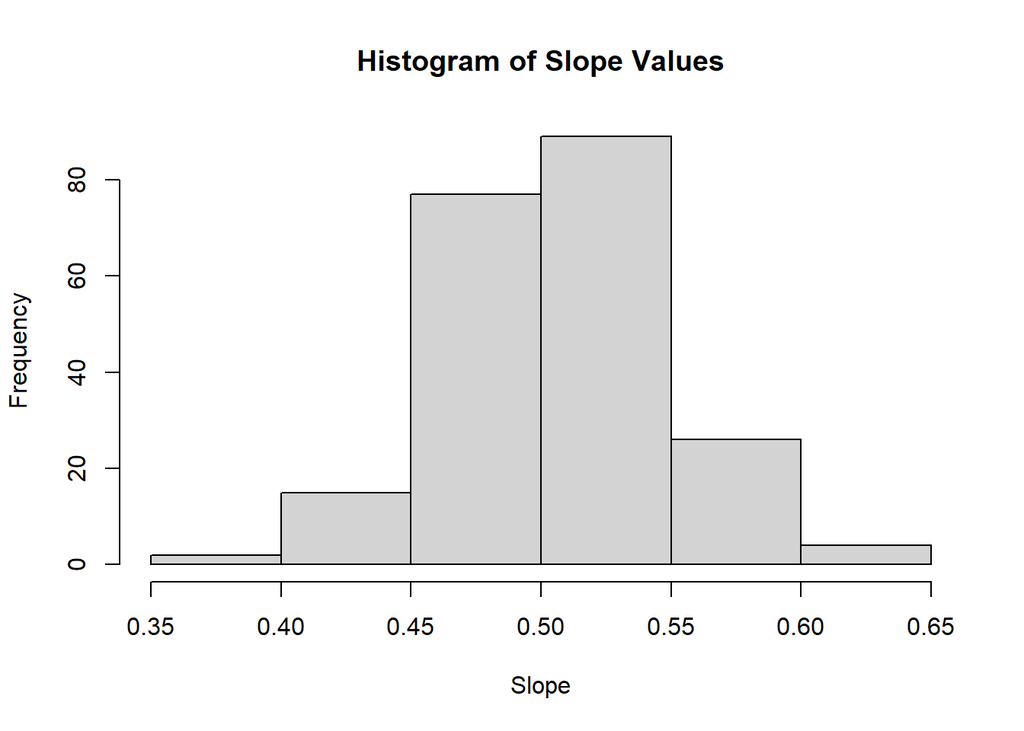

```r
# histogram for slope β1
hist(Brain_Range_Boot$slope,
  main = "Histogram of Slope Values",
  xlab = "Slope")
```

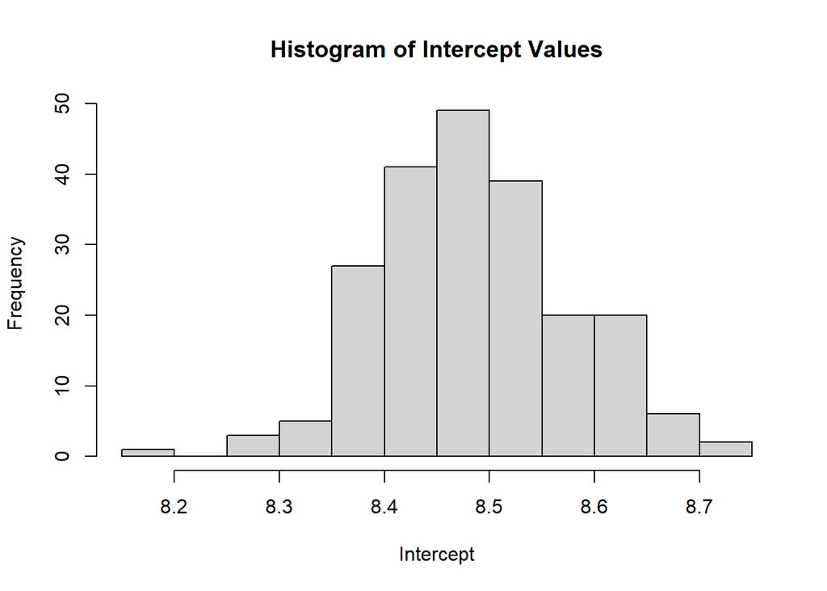

```r
# histogram for intercept β0
hist(Brain_Range_Boot$intercept,
  main = "Histogram of Intercept Values",
  xlab = "Intercept")
```

### Estimate the standard error for each of your β coefficients as the standard deviation of the sampling distribution from your bootstrap.

```r
# first define alpha, CI boundaries, and critical values
alpha <- 0.05
confidence_level <- 1 - alpha
p_lower <- alpha / 2
p_upper <- 1 - (alpha / 2)
degrees_of_freedom <- nrow(Brain_Range_Boot) - 2
critical_value <- qt(p_upper, df = degrees_of_freedom)

# β1
Brain_Range_Boot_ErrorS <- Brain_Range_Boot %>%
  summarize(
    estimate = mean(slope),
    std.error = sd(slope),
    lower = estimate - std.error * critical_value,
    upper = estimate + std.error * critical_value,
    boot.lower = quantile(slope, p_lower),
    boot.upper = quantile(slope, p_upper)
    )
Brain_Range_Boot_ErrorS
```

```
## # A tibble: 1 x 6
##   estimate std.error lower upper boot.lower boot.upper
##      <dbl>     <dbl> <dbl> <dbl>      <dbl>      <dbl>
## 1    0.506    0.0425 0.422 0.590      0.427      0.587
```

```r
# β0
Brain_Range_Boot_ErrorI <- Brain_Range_Boot %>%
  summarize(
    estimate = mean(intercept),
    std.error = sd(intercept),
    lower = estimate - std.error * critical_value,
    upper = estimate + std.error * critical_value,
    boot.lower = quantile(slope, p_lower),
    boot.upper = quantile(slope, p_upper)
    )
Brain_Range_Boot_ErrorI
```

```
## # A tibble: 1 x 6
##   estimate std.error lower upper boot.lower boot.upper
##      <dbl>     <dbl> <dbl> <dbl>      <dbl>      <dbl>
## 1     8.49    0.0887  8.31  8.66      0.427      0.587
```

### How do you bootstrap CIs compare to those estimated mathematically as part of the lm() function?

```r
alpha = 0.05
# extract CIs from the model with
# using the results of lm()
(CI <- confint(rangeLM, level = 1 - alpha))
```

```
##                 2.5 %    97.5 %
## (Intercept) 8.2844504 8.6878632
## logHOMER    0.4243665 0.5883935
```

## Challenge 3

### Write your own function, called boot_lm()

```r
boot_lm <- function(d, model, conf.level=0.95, reps=1000){

# 1. Add data to d and log values
 d <- d %>%
   mutate(log_HomeRange = log(HomeRange_km2),
      log_BMASSFM = log(Body_mass_female_mean),
      log_DayLength = log(DayLength_km),
      log_MGS = log(MeanGroupSize))

# 2. What is the structure of 'model'
model <- as.formula(model)
fit <- lm(model, data = d)

# 3. bootstrappin'
bootsbewalkin <- d %>%
# generate bootstrap replicates
generate(reps = reps, type = "bootstrap")
slope <- vector()
intercept <- vector()

# now rep function
for (i in 1:213) {
  Range_Boot <- filter(bootsbewalkin, replicate == i)
  Range_Bootlm <- lm(model, Range_Boot)
  slope[[i]] <- Range_Bootlm$coefficients[[2]]
  intercept[[i]] <- Range_Bootlm$coefficients[[1]]
}

# 4. store vectors for accesibilty
Range_Boot <- tibble(slope = slope, intercept = intercept)

# 5. define alpha, CI boundaries, and critical values
alpha <- 0.05
confidence_level <- 1 - alpha
p_lower <- alpha / 2
p_upper <- 1 - (alpha / 2)
degrees_of_freedom <- nrow(Range_Boot) - 2
critical_value <- qt(p_upper, df = degrees_of_freedom)

# 5a. Slope β1
Range_Bootlm_ErrorS <- Range_Boot %>%
  summarize(
    estimate = mean(slope),
    std.error = sd(slope),
    lower = estimate - std.error * critical_value,
    upper = estimate + std.error * critical_value,
    boot.lower = quantile(slope, p_lower),
    boot.upper = quantile(slope, p_upper)
    )
Range_Bootlm_ErrorS

# 5b. Intercept β0
Range_Bootlm_ErrorI <- Range_Boot %>%
  summarize(
    estimate = mean(intercept),
    std.error = sd(intercept),
    lower = estimate - std.error * critical_value,
    upper = estimate + std.error * critical_value,
    boot.lower = quantile(slope, p_lower),
    boot.upper = quantile(slope, p_upper)
    )
Range_Bootlm_ErrorI

# combined
C <-rbind(Range_Bootlm_ErrorS,Range_Bootlm_ErrorI)
C
}
```

### log(HomeRange_km2) ~ log(Body_mass_female_mean)

```r
boot_lm(d = data, model = "log_HomeRange ~ log_BMASSFM")
```

```
## # A tibble: 2 x 6
##   estimate std.error   lower upper boot.lower boot.upper
##      <dbl>     <dbl>   <dbl> <dbl>      <dbl>      <dbl>
## 1     1.05    0.0708   0.906  1.18      0.909       1.18
## 2    -9.51    0.564  -10.6   -8.40      0.909       1.18
```

### log(DayLength_km) ~ log(Body_mass_female_mean)

```r
boot_lm(d = data, model = "log_DayLength ~ log_BMASSFM")
```

```
## # A tibble: 2 x 6
##   estimate std.error   lower upper boot.lower boot.upper
##      <dbl>     <dbl>   <dbl> <dbl>      <dbl>      <dbl>
## 1   0.0392    0.0605 -0.0801 0.159    -0.0719      0.150
## 2  -0.146     0.471  -1.07   0.782    -0.0719      0.150
```

### log(HomeRange_km2) ~ log(Body_mass_female_mean) + MeanGroupSize

```r
boot_lm(d = data, model = "log_HomeRange ~ log_BMASSFM + log_MGS")
```

```
## # A tibble: 2 x 6
##   estimate std.error  lower  upper boot.lower boot.upper
##      <dbl>     <dbl>  <dbl>  <dbl>      <dbl>      <dbl>
## 1    0.753    0.0969  0.562  0.944      0.549      0.931
## 2   -8.75     0.612  -9.96  -7.55       0.549      0.931
```